# Reproducible research of the most health harmful and economic losses disaster

## Synopsis

This research involves exploring the U.S. National Oceanic and Atmospheric Administration’s (NOAA) storm database. This database tracks characteristics of major storms and weather events in the United States, including when and where they occur, as well as estimates of any fatalities, injuries, and property damage. This research focus on finding the most harmful and economic losses disaster in the database by addressing two questions. first, which types of events are most harmful with respect to population health? second, which types of events have the greatest economic consequences? By analyzing those answers relate to the two issues, we can get the key result of this report.

## Data Processing

### getting data in R

Loading necessary Packages

```r
suppressMessages(library(knitr))
suppressMessages(library(dplyr))
library(knitr)
library(dplyr)
```

Download and read the data

```r
url <- 'https://d396qusza40orc.cloudfront.net/repdata%2Fdata%2FStormData.csv.bz2'

filename <- "Storm Data.csv.bz2"
localfile <- file.path(getwd(),filename)
if(!file.exists(filename)){
        download.file(url, localfile, method = "curl")
        dateDownloaded <- date()
        message('完成数据下载: ', dateDownloaded)
}
stormData<-read.csv(filename,
                    header = TRUE,
                    sep = ',',
                    quote = "\"",
                    stringsAsFactors = F)
```

### Most harmful events

Prepare the tbl type data

```r
TableStormData <- tbl_df(stormData)
```

First, select coloums relvent to disaster type and population health. then calculate the number of fatalities and injuries of each type of events. finally, arrange the result to get the top 10 events stored in the Top10Data variavle.

```r
SumStormData <-
        select(TableStormData, EVTYPE, FATALITIES, INJURIES) %>%
        group_by(EVTYPE) %>%
        summarize(sum=sum(FATALITIES, INJURIES)) %>%
        arrange(desc(sum))
Top10Data<-SumStormData[1:10,]
```

Plot the data using barplot function in r.

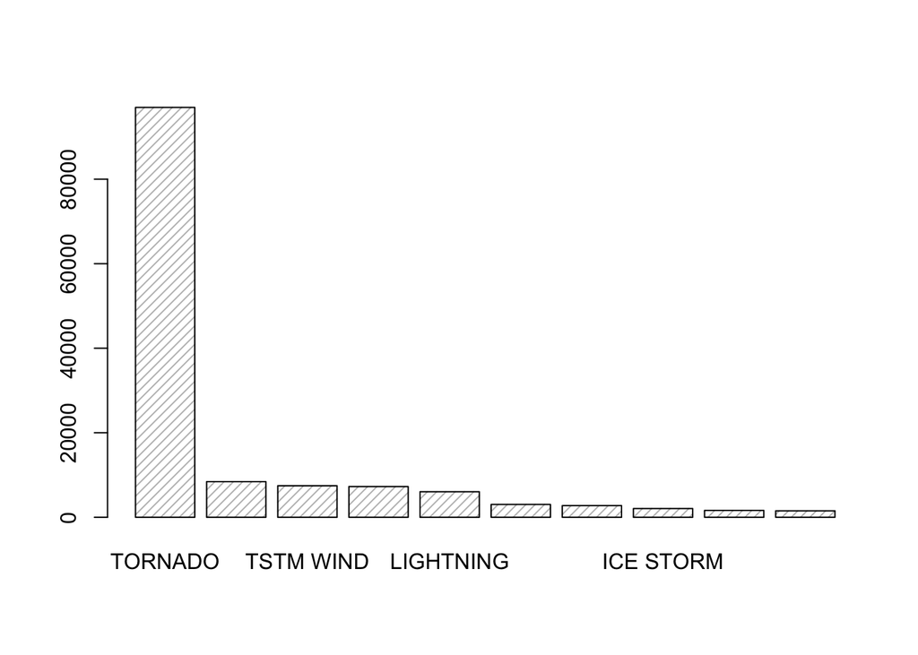

```r
barplot(Top10Data$sum,density = 20,names.arg=Top10Data$EVTYPE)
```

As the barplot shown above, Tornado is the most harmful event which causes likely 10 times more death and injuries than other events.

### Greatest economic consequences events

First, define a function called setnum to transform number unit like ‘k’ which stands for thousand to 1000.

```r
setnum<-function(a){
        if((a=='K')|(a=='k')){a<-1000}
        else if((a=='M')|(a=='m')){a<-1000000}
        else if((a=='B')|(a=='b')){a<-1000000000}
        else if((a=='H')|(a=='h')){a<-100}
        else{a<-1}
}
```

Second, define a function called multiply to calculate times.

```r
multiply<-function(x,y){
        x*y
}
```

Third, Using lapply and setnum funciton which we defined before to transform number unit to real number. This step helps us do the calculation more conveniently next.

```r
DmgStormData <- select(TableStormData,
                       EVTYPE, PROPDMG, PROPDMGEXP, CROPDMG, CROPDMGEXP)
m<-lapply(DmgStormData$PROPDMGEXP,FUN = setnum)
DmgStormData$PROPDMGEXP<-unlist(m)
m<-lapply(DmgStormData$CROPDMGEXP,FUN = setnum)
DmgStormData$CROPDMGEXP<-unlist(m)
```

Forth, calculaten the total cost of each peticular type of disaster, and arrange the result to get the top 10 values.

```r
CostStormData <-
        mutate(DmgStormData, PROPs=multiply(PROPDMG, PROPDMGEXP)) %>%
        mutate(CROPs=multiply(CROPDMG, CROPDMGEXP)) %>%
        select(EVTYPE,PROPs,CROPs) %>%
        group_by(EVTYPE) %>%
        summarize(sum=sum(PROPs,CROPs)) %>%
        arrange(desc(sum))
Top10Cost<-CostStormData[1:10,]
```

Ploting the data using barplot function.

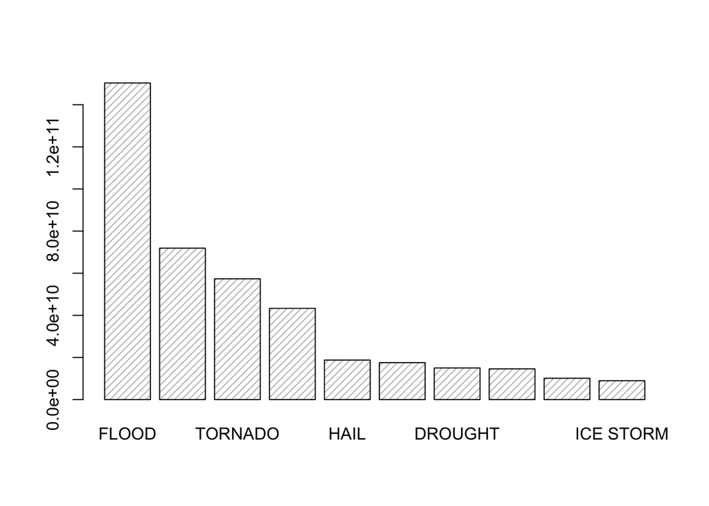

```r
barplot(Top10Cost$sum,density = 20,names.arg=Top10Cost$EVTYPE)
```

As shown in the figure above, flood is greatest economic consequences event. What’s worth note is Tornado which again got a high rank in this plot.